# UNO Vision — IAPR 2026 Final Report

**Task:** For each UNO game image (4000×2662 px), predict:

- The **center card** played in the middle
- The **active player** (p1/p2/p3/p4) — the one holding the token
- The **hand cards** of each of the 4 players

**Metric:** `Score = 0.1·CenterAcc + 0.1·ActiveAcc + 0.8·F1` (multi-set F1 over player cards)

**Constraints:**

- No external datasets or pre-trained models
- ≤ 12M parameters total across all models
- 81 annotated training images + 159 test images

## Pipeline overview

[output not shown]

```python
import sys
from pathlib import Path

import cv2
import numpy as np
import pandas as pd
import matplotlib.pyplot as plt
import matplotlib.patches as mpatches
import torch

ROOT = Path('..').resolve()
sys.path.insert(0, str(ROOT))

from src.config import (
    CARD_CLASSES, NUM_CLASSES, TRAIN_DIR, TRAIN_CSV,
    REFERENCE_DIR, DATA_DIR, MODELS_DIR
)

TEMPLATES_DIR = DATA_DIR / 'card_templates'
CLASSIFIER_PT = MODELS_DIR / 'classifier.pt'
DETECTOR_PT   = MODELS_DIR / 'detector.pt'

print(f'Train images : {len(list(TRAIN_DIR.glob("*.jpg")))}')
print(f'Card classes : {NUM_CLASSES}')
print(f'Classifier   : {CLASSIFIER_PT.exists()}')
print(f'Detector     : {DETECTOR_PT.exists()}')
```

```
Train images : 81
Card classes : 54
Classifier   : True
Detector     : True
```

## 1. Dataset

81 annotated training images. Each row of `train.csv` gives the center card, active player, and hand cards for all 4 players.

```python
df = pd.read_csv(TRAIN_CSV)
print(f'Shape: {df.shape}')
df.head(5)
```

```
Shape: (81, 7)
```

|  | image_id | center_card | active_player | player_1_cards | player_2_cards | player_3_cards | player_4_cards |
| --- | --- | --- | --- | --- | --- | --- | --- |
| 0 | L1000770 | y_1 | p3 | EMPTY | y_4;g_2;r_3 | r_skip;y_2;b_5 | EMPTY |
| 1 | L1000771 | r_5 | p1 | y_7;y_8;g_4 | EMPTY | r_9;y_0 | EMPTY |
| 2 | L1000772 | r_9 | p2 | y_8;b_6;g_3 | b_skip;r_0;r_3 | r_6;g_2;r_9 | b_draw_2;y_7 |
| 3 | L1000773 | y_8 | p4 | r_1;wild;g_2 | EMPTY | draw_4;g_reverse;y_1 | y_reverse;r_3 |
| 4 | L1000774 | r_4 | p3 | g_4;g_8;r_7;b_3 | r_9;g_3 | wild;y_3;r_8 | b_7;b_6 |

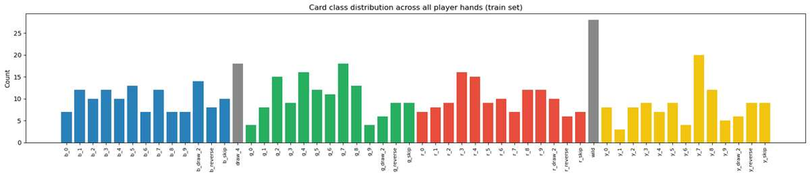

```
Total card instances in training annotations: 546
```

```python
# Class distribution across all player hands
all_cards = []
for col in ['player_1_cards','player_2_cards','player_3_cards','player_4_cards']:
    for hand in df[col].dropna():
        if hand != 'EMPTY':
            all_cards.extend(hand.split(';'))

from collections import Counter
counts = Counter(all_cards)
labels_sorted = sorted(counts.keys())
values = [counts[l] for l in labels_sorted]

color_map = {'r': '#e74c3c', 'g': '#27ae60', 'b': '#2980b9', 'y': '#f1c40f',
             'w': '#888888', 'd': '#888888'}
bar_colors = [color_map.get(l[0], '#888888') for l in labels_sorted]

fig, ax = plt.subplots(figsize=(18, 4))
ax.bar(range(len(labels_sorted)), values, color=bar_colors)
ax.set_xticks(range(len(labels_sorted)))
ax.set_xticklabels(labels_sorted, rotation=90, fontsize=8)
ax.set_title('Card class distribution across all player hands (train set)')
ax.set_ylabel('Count')
plt.tight_layout()
plt.show()

print(f'Total card instances in training annotations: {sum(values)}')
```

[figure not shown]

```python
# Show 4 training scenes
sample_ids = df['image_id'].tolist()[:4]
fig, axes = plt.subplots(1, 4, figsize=(20, 5))
for ax, img_id in zip(axes, sample_ids):
    img = cv2.imread(str(TRAIN_DIR / f'{img_id}.jpg'))
    ax.imshow(cv2.cvtColor(img, cv2.COLOR_BGR2RGB))
    row = df[df.image_id == img_id].iloc[0]
    ax.set_title(f'{img_id}\ncenter={row.center_card}  active={row.active_player}', fontsize=8)
    ax.axis('off')
plt.suptitle('Sample training images', fontsize=12)
plt.tight_layout()
plt.show()
```

## 2. Template extraction

The 54 UNO card templates are extracted from the official `reference_images` via HSV segmentation + color-based matching. These form the seed of our synthetic training dataset.

```
Templates found: 54
```

[figure not shown]

```python
template_files = sorted(TEMPLATES_DIR.glob('*.png')) if TEMPLATES_DIR.exists() else []
print(f'Templates found: {len(template_files)}')

if template_files:
    # Build a grid: 9 cols × 6 rows
    cols, rows = 9, 6
    thumb_w, thumb_h = 100, 150
    canvas = np.ones((rows * thumb_h + rows * 4, cols * thumb_w + cols * 4, 3),
                      dtype=np.uint8) * 240
    for i, f in enumerate(template_files[:cols * rows]):
        r, c = divmod(i, cols)
        img = cv2.imread(str(f))
        img = cv2.resize(img, (thumb_w, thumb_h))
        y0, x0 = r * (thumb_h + 4), c * (thumb_w + 4)
        canvas[y0:y0+thumb_h, x0:x0+thumb_w] = img

    fig, ax = plt.subplots(figsize=(18, 12))
    ax.imshow(cv2.cvtColor(canvas, cv2.COLOR_BGR2RGB))
    ax.axis('off')
    ax.set_title('54 UNO card templates extracted from reference_images', fontsize=13)
    plt.tight_layout()
    plt.show()
else:
    print('Run scripts/extract_templates.py first to generate card_templates/')
```

## 3. Architecture

### 3.1 Classifier — UnoCNN (ResNet-18-light, 11.20M params)

```
Input: 144×96 RGB crop
  Stem   : Conv3×3 3→64 (no stride — preserve local features)
  Stage1 : 2× BasicBlock 64→64
  Stage2 : 2× BasicBlock 64→128  (stride 2)
  Stage3 : 2× BasicBlock 128→256 (stride 2)
  Stage4 : 2× BasicBlock 256→512 (stride 2)
  Head   : GAP → Dropout(0.3) → Linear(512, 54)
Output: 54 logits (one per UNO card class)
```

BasicBlock = Conv3×3 + BN + ReLU + Conv3×3 + BN + residual skip. Skip connections prevent gradient vanishing — crucial for distinguishing visually similar classes (e.g. `y_8` vs `y_9`, `b_skip` vs `b_reverse`).

### 3.2 Detector — CenterNet-style anchor-free (0.53M params)

```
Input: 512×352 image
  Stem  : Conv3×3 3→16 (stride 2)  → 256×176
  Stage1: 2× BasicBlock 16→32 (stride 2) → 128×88
  Stage2: 2× BasicBlock 32→64 (stride 2) → 64×44
  Stage3: 2× BasicBlock 64→96 (stride 2) → 32×22
  Head  : Conv3×3 96→64
    ├── head_obj  : Conv1×1 64→1  (objectness heatmap, logits)
    └── head_bbox : Conv1×1 64→4  (cx_norm, cy_norm, w_norm, h_norm → sigmoid)
```

Trained on 626 manually annotated bboxes (LabelImg, YOLO format). Loss = Focal(α=2,β=4) on heatmap + L1 on bbox at peak pixel.

**Total: 0.53M + 11.20M = 11.73M < 12M limit ✓**

```python
from src.model import UnoCNN, count_parameters as count_clf
from src.detector import CardDetector, count_parameters as count_det

clf_model = UnoCNN()
det_model = CardDetector()

n_clf = count_clf(clf_model)
n_det = count_det(det_model)
n_total = n_clf + n_det

print(f'Classifier  (UnoCNN)      : {n_clf:>12,} params')
print(f'Detector    (CenterNet)   : {n_det:>12,} params')
print(f'Total                     : {n_total:>12,} params')
print(f'Under 12M limit           : {n_total < 12_000_000}')

# Verify forward pass shapes
x_clf = torch.randn(2, 3, 144, 96)
x_det = torch.randn(1, 3, 352, 512)
y_clf = clf_model(x_clf)
y_det = det_model(x_det)
print(f'\nClassifier  : {tuple(x_clf.shape)} → {tuple(y_clf.shape)}')
print(f'Detector obj: {tuple(x_det.shape)} → {tuple(y_det["obj"].shape)}')
print(f'Detector box: {tuple(x_det.shape)} → {tuple(y_det["bbox"].shape)}')
```

```
Classifier  (UnoCNN)      :   11,196,534 params
Detector    (CenterNet)   :      532,245 params
Total                     :   11,728,779 params
Under 12M limit           : True

Classifier  : (2, 3, 144, 96) → (2, 54)
Detector obj: (1, 3, 352, 512) → (1, 1, 22, 32)
Detector box: (1, 3, 352, 512) → (1, 4, 22, 32)
```

## 4. Augmentation strategy

The classifier is trained **from scratch** on synthetic crops generated from the 54 templates — no real crop annotations available initially. Augmentations simulate what the detector will pass downstream:

| Transform | Range / Prob |
| --- | --- |
| Discrete rotation | {0°, 90°, 180°, 270°} |
| Fine tilt | ±15° |
| Perspective jitter | ±12 px per corner (p=0.7) |
| Scale | 0.88–1.10× |
| Brightness | ±50 |
| Contrast | ×0.65–1.35 |
| Saturation | ×0.55–1.45 |
| Hue | ±8° |
| Gaussian blur | σ≤2.0 (p=0.5) |
| Gaussian noise | σ≤14 (p=0.6) |
| BG fringe | 60% — card shrunk to 82–98%, placed on white/noisy synthetic bg |

**BG fringe** is critical: detections often capture a few pixels of background at borders. Without it, the classifier overfits to clean centered templates and fails on real crops.

[figure not shown]

```python
from src.augmentation import augment, AugConfig

# Pick one template to visualize augmentations
tpl_files = sorted(TEMPLATES_DIR.glob('*.png')) if TEMPLATES_DIR.exists() else []

if tpl_files:
    rng = np.random.default_rng(42)
    template = cv2.imread(str(tpl_files[0]))  # e.g. b_0
    cfg = AugConfig()

    n_aug = 8
    fig, axes = plt.subplots(1, n_aug + 1, figsize=(20, 4))
    axes[0].imshow(cv2.cvtColor(template, cv2.COLOR_BGR2RGB))
    axes[0].set_title(f'Original\n{tpl_files[0].stem}', fontsize=9)
    axes[0].axis('off')
    for i in range(n_aug):
        aug = augment(template, rng, cfg)
        axes[i+1].imshow(cv2.cvtColor(aug, cv2.COLOR_BGR2RGB))
        axes[i+1].set_title(f'Aug #{i+1}', fontsize=9)
        axes[i+1].axis('off')
    plt.suptitle('Template → synthetic augmentations', fontsize=12)
    plt.tight_layout()
    plt.show()
else:
    print('Run scripts/extract_templates.py first.')
```

## 5. Auto-labeling of real crops (key contribution)

A classifier trained only on synthetic crops fails on real game images: the distribution gap (bg leakage, blur, reflections) is too large.

**Solution:** use the 81 GT-annotated train images to auto-label real crops:

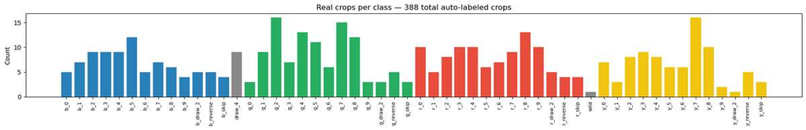

[figure not shown]

```python
REAL_CROPS_DIR = DATA_DIR / 'real_crops'

if REAL_CROPS_DIR.exists():
    all_real = list(REAL_CROPS_DIR.glob('*/*.png'))
    label_counts = Counter(f.parent.name for f in all_real)
    labels_r = sorted(label_counts.keys())
    values_r = [label_counts[l] for l in labels_r]
    bar_colors_r = [color_map.get(l[0], '#888888') for l in labels_r]

    fig, ax = plt.subplots(figsize=(18, 3))
    ax.bar(range(len(labels_r)), values_r, color=bar_colors_r)
    ax.set_xticks(range(len(labels_r)))
    ax.set_xticklabels(labels_r, rotation=90, fontsize=8)
    ax.set_title(f'Real crops per class — {len(all_real)} total auto-labeled crops')
    ax.set_ylabel('Count')
    plt.tight_layout()
    plt.show()

    # Show a few real crops vs their template
    sample_labels = [l for l in labels_r if label_counts[l] >= 3][:5]
    n_show = 4
    fig, axes = plt.subplots(len(sample_labels), n_show + 1, figsize=(14, 3*len(sample_labels)))
    for row_i, lbl in enumerate(sample_labels):
        tpl_path = TEMPLATES_DIR / f'{lbl}.png'
        tpl_img = cv2.imread(str(tpl_path)) if tpl_path.exists() else np.zeros((200,133,3),np.uint8)
        axes[row_i][0].imshow(cv2.cvtColor(tpl_img, cv2.COLOR_BGR2RGB))
        axes[row_i][0].set_title(f'{lbl}\n(template)', fontsize=8)
        axes[row_i][0].axis('off')
        crops = sorted((REAL_CROPS_DIR / lbl).glob('*.png'))[:n_show]
        for j, cp in enumerate(crops):
            cimg = cv2.imread(str(cp))
            axes[row_i][j+1].imshow(cv2.cvtColor(cimg, cv2.COLOR_BGR2RGB))
            axes[row_i][j+1].set_title(f'real #{j+1}', fontsize=8)
            axes[row_i][j+1].axis('off')
        for j in range(len(crops), n_show):
            axes[row_i][j+1].axis('off')
    plt.suptitle('Template vs auto-labeled real crops', fontsize=12)
    plt.tight_layout()
    plt.show()
else:
    print('Run scripts/autolabel_train.py first to generate data/real_crops/')
```

## 6. Loading the trained models

```python
from src.inference import Classifier, predict_scene
from src.detector_inference import CardDetectorRuntime

classifier = Classifier(CLASSIFIER_PT)
detector   = CardDetectorRuntime(DETECTOR_PT, device=str(classifier.device))

print(f'Classifier loaded  — device: {classifier.device}')
print(f'Detector   loaded  — device: {classifier.device}')
```

```
Classifier loaded  — device: cpu
Detector   loaded  — device: cpu
```

## 7. Card detection visualization

The detection is **hybrid**: heuristic HSV on the center zone, learned CenterNet on player zones.

- **Heuristic** (white background): Gaussian blur on HSV saturation → threshold → contours → rotated rects. Stacks split by k-means color.
- **Heuristic** (noisy background): enclosed white ovals in the saturation mask → infer card rect by scaling (×1.55).
- **Learned detector**: anchor-free CenterNet on 512×352 resized input → objectness heatmap + bbox regression → NMS.

[figure not shown]

```python
from src.detection import detect_cards_in_scene, detect_active_token
from src.detector_inference import detect_cards_with_model
from src.inference import predict_scene

def draw_detections(image, cards, token=None, title=''):
    vis = image.copy()
    for c in cards:
        box = cv2.boxPoints(c['rect']).astype(np.intp)
        cv2.drawContours(vis, [box], 0, (0, 220, 0), 6)
        cx, cy = int(c['cx']), int(c['cy'])
        cv2.circle(vis, (cx, cy), 10, (0, 220, 0), -1)
    if token:
        tx, ty = int(token[0]), int(token[1])
        cv2.circle(vis, (tx, ty), 60, (255, 140, 0), 10)
        cv2.circle(vis, (tx, ty), 10, (255, 140, 0), -1)
    return vis

# Pick one white-bg and one noisy-bg image
sample_pairs = [('L1000770', 'White background'), ('L1000909', 'Noisy background')]

fig, axes = plt.subplots(1, 2, figsize=(18, 7))
for ax, (img_id, bg_type) in zip(axes, sample_pairs):
    img_path = TRAIN_DIR / f'{img_id}.jpg'
    if not img_path.exists():
        ax.set_title(f'{img_id} not found — download data first')
        ax.axis('off')
        continue
    img = cv2.imread(str(img_path))
    token = detect_active_token(img)
    cards_heur = detect_cards_in_scene(img, exclude_xy=token)
    vis = draw_detections(img, cards_heur, token)
    ax.imshow(cv2.cvtColor(vis, cv2.COLOR_BGR2RGB))
    ax.set_title(f'{bg_type} — {img_id}\nHeuristic: {len(cards_heur)} cards detected', fontsize=10)
    ax.axis('off')

plt.suptitle('Heuristic card detection (green boxes) + token (orange)', fontsize=12)
plt.tight_layout()
plt.show()
```

[figure not shown]

```
Heatmap max: 0.993  |  Pixels > 0.35: 10
```

```python
# Learned detector heatmap visualization
from src.detector_dataset import INPUT_H, INPUT_W

img_id = 'L1000770'
img_path = TRAIN_DIR / f'{img_id}.jpg'

if img_path.exists():
    img = cv2.imread(str(img_path))
    img_resized = cv2.resize(img, (INPUT_W, INPUT_H))
    img_rgb = cv2.cvtColor(img_resized, cv2.COLOR_BGR2RGB)
    tensor = torch.from_numpy(img_rgb).permute(2,0,1).float().unsqueeze(0) / 255.0
    tensor = tensor.to(classifier.device)

    with torch.no_grad():
        out = detector.model(tensor)
    heatmap = torch.sigmoid(out['obj'])[0, 0].cpu().numpy()

    fig, axes = plt.subplots(1, 3, figsize=(18, 5))
    axes[0].imshow(img_rgb)
    axes[0].set_title(f'Input image (resized to {INPUT_W}×{INPUT_H})', fontsize=10)
    axes[0].axis('off')

    im = axes[1].imshow(heatmap, cmap='hot', vmin=0, vmax=1)
    plt.colorbar(im, ax=axes[1])
    axes[1].set_title(f'Objectness heatmap ({heatmap.shape[1]}×{heatmap.shape[0]} grid)', fontsize=10)
    axes[1].axis('off')

    # Overlay heatmap on image
    hm_up = cv2.resize(heatmap, (INPUT_W, INPUT_H))
    hm_colored = plt.cm.hot(hm_up)[:,:,:3]
    overlay = 0.5 * img_rgb / 255.0 + 0.5 * hm_colored
    overlay = np.clip(overlay, 0, 1)
    axes[2].imshow(overlay)
    axes[2].set_title('Heatmap overlay', fontsize=10)
    axes[2].axis('off')

    plt.suptitle(f'CenterNet detector — objectness heatmap for {img_id}', fontsize=12)
    plt.tight_layout()
    plt.show()
    print(f'Heatmap max: {heatmap.max():.3f}  |  Pixels > 0.35: {(heatmap > 0.35).sum()}')
else:
    print('Download data first.')
```

## 8. Full pipeline inference — Predictions vs Ground Truth

For each image we run the full hybrid pipeline and display:

- Detected card bounding boxes colored by player zone
- Predicted labels on each card
- Ground truth comparison (green = correct, red = wrong)
- Center card and active player prediction

```python
from src.detection import assign_player

ZONE_COLORS_BGR = {
    'p1': (50, 205, 50),    # green
    'p2': (255, 100, 20),   # orange
    'p3': (60, 60, 255),    # red
    'p4': (255, 30, 255),   # magenta
    'center': (0, 200, 255),# yellow
}

def parse_hand(s):
    return [] if (not s or s == 'EMPTY') else str(s).split(';')

def f1_multiset(pred, gt):
    pc, gc = Counter(pred), Counter(gt)
    tp = sum(min(pc.get(k,0), gc.get(k,0)) for k in set(pc)|set(gc))
    fp = sum(pc.values()) - tp
    fn = sum(gc.values()) - tp
    if 2*tp+fp+fn == 0: return 1.0
    return 2*tp / (2*tp+fp+fn)

def visualize_prediction(img_id, df, classifier, detector,
                          confidence_threshold=0.40, use_tta=True):
    img_path = TRAIN_DIR / f'{img_id}.jpg'
    if not img_path.exists():
        print(f'{img_id} not found'); return

    img = cv2.imread(str(img_path))
    h0, w0 = img.shape[:2]

    pred = predict_scene(img, img_id, classifier,
                         confidence_threshold=confidence_threshold,
                         use_tta=use_tta,
                         detector=detector,
                         hybrid=True)

    gt_row = df[df.image_id == img_id].iloc[0]
    gt_center = gt_row.center_card
    gt_active = gt_row.active_player
    gt_cards = {f'p{i}': parse_hand(getattr(gt_row, f'player_{i}_cards')) for i in range(1,5)}

    # Build annotation overlay
    scale = 1200 / w0
    vis_small = cv2.resize(img, (1200, int(h0 * scale)))

    from src.detection import detect_active_token, detect_cards_in_scene
    from src.detector_inference import detect_cards_with_model

    token = detect_active_token(img)
    heur_cards = detect_cards_in_scene(img, exclude_xy=token)
    model_cards = detect_cards_with_model(img, detector, exclude_xy=token)

    # Merge: heuristic for center, model for players
    all_cards = ([c for c in heur_cards if assign_player(c['cx'], c['cy'], img.shape) == 'center']
               + [c for c in model_cards if assign_player(c['cx'], c['cy'], img.shape) != 'center'])

    # Classify
    crops = [c['warped'] for c in all_cards]
    if crops:
        probs = classifier.classify_full_tta(crops) if use_tta else classifier.classify_full(crops)
        from src.config import IDX_TO_CLASS
        for i, card in enumerate(all_cards):
            idx = int(probs[i].argmax())
            card['label'] = IDX_TO_CLASS[idx]
            card['confidence'] = float(probs[i, idx])

    # Draw on vis_small
    for c in all_cards:
        zone = assign_player(c['cx'], c['cy'], img.shape)
        color = ZONE_COLORS_BGR.get(zone, (200, 200, 200))
        box = cv2.boxPoints(c['rect']).astype(np.float32)
        box *= scale
        box = box.astype(np.intp)
        cv2.drawContours(vis_small, [box], 0, color, 3)
        lbl = c.get('label', '?')
        conf = c.get('confidence', 0)
        if conf >= confidence_threshold:
            cx_s, cy_s = int(c['cx'] * scale), int(c['cy'] * scale)
            cv2.putText(vis_small, lbl, (cx_s - 40, cy_s),
                        cv2.FONT_HERSHEY_SIMPLEX, 0.5, color, 2)
    if token:
        tx, ty = int(token[0]*scale), int(token[1]*scale)
        cv2.circle(vis_small, (tx, ty), int(50*scale), (255, 140, 0), 5)

    # Compute scores
    center_ok = pred.center_card == gt_center
    active_ok = pred.active_player == gt_active
    gt_all = sum(gt_cards.values(), [])
    pred_all = sum(pred.player_cards.values(), [])
    f1 = f1_multiset(pred_all, gt_all)
    score = 0.1*center_ok + 0.1*active_ok + 0.8*f1

    # Figure
    fig = plt.figure(figsize=(20, 12))
    gs = fig.add_gridspec(2, 2, height_ratios=[3,1])

    ax_img = fig.add_subplot(gs[0, :])
    ax_img.imshow(cv2.cvtColor(vis_small, cv2.COLOR_BGR2RGB))
    ax_img.set_title(
        f'{img_id}  |  Score={score:.3f}  |  '
        f'CenterAcc={int(center_ok)}  ActiveAcc={int(active_ok)}  F1={f1:.3f}',
        fontsize=12
    )
    ax_img.axis('off')

    # Legend for zones
    patches = [mpatches.Patch(color=np.array(c[::-1])/255, label=z)
               for z, c in ZONE_COLORS_BGR.items()]
    ax_img.legend(handles=patches, loc='lower right', fontsize=9, ncol=5)

    # GT vs Pred table
    ax_table = fig.add_subplot(gs[1, :])
    ax_table.axis('off')

    rows_data = []
    row_colors = []

    # Center card row
    rows_data.append(['CENTER', gt_center, pred.center_card, 'OK' if center_ok else 'WRONG'])
    row_colors.append(['#dddddd', '#c8f0c8' if center_ok else '#f0c8c8',
                        '#c8f0c8' if center_ok else '#f0c8c8',
                        '#c8f0c8' if center_ok else '#f0c8c8'])

    # Active player row
    rows_data.append(['ACTIVE', gt_active, pred.active_player, 'OK' if active_ok else 'WRONG'])
    row_colors.append(['#dddddd', '#c8f0c8' if active_ok else '#f0c8c8',
                        '#c8f0c8' if active_ok else '#f0c8c8',
                        '#c8f0c8' if active_ok else '#f0c8c8'])

    # Player hand rows
    for pi in range(1, 5):
        slot = f'p{pi}'
        gt_h  = sorted(gt_cards[slot])
        pred_h = sorted(pred.player_cards[slot])
        hand_f1 = f1_multiset(pred_h, gt_h)
        match = hand_f1 == 1.0
        rows_data.append([slot.upper(),
                           ' '.join(gt_h) or 'EMPTY',
                           ' '.join(pred_h) or 'EMPTY',
                           f'F1={hand_f1:.2f}'])
        row_colors.append(['#dddddd',
                            '#c8f0c8' if match else '#f0c8c8',
                            '#c8f0c8' if match else '#f0c8c8',
                            '#c8f0c8' if match else '#ffe0a0'])

    table = ax_table.table(
        cellText=rows_data,
        colLabels=['', 'Ground Truth', 'Predicted', 'Result'],
        cellLoc='center', loc='center',
        cellColours=row_colors
    )
    table.auto_set_font_size(False)
    table.set_fontsize(9)
    table.scale(1, 1.6)

    plt.tight_layout()
    plt.show()

    return score, center_ok, active_ok, f1

print('visualize_prediction() defined')
```

```
visualize_prediction() defined
```

[figure not shown]

```
(1.0, True, True, 1.0)
```

```python
# Run on a white-background image
visualize_prediction('L1000770', df, classifier, detector, use_tta=True)
```

[figure not shown]

```
(1.0, True, True, 1.0)
```

```python
# Run on a noisy-background image
visualize_prediction('L1000909', df, classifier, detector, use_tta=True)
```

[figure not shown]

[figure not shown]

```python
# Two more examples
for img_id in ['L1000780', 'L1000840']:
    if (TRAIN_DIR / f'{img_id}.jpg').exists():
        visualize_prediction(img_id, df, classifier, detector, use_tta=True)
```

## 9. Quantitative evaluation on 81 training images

Metric: `Score = 0.1·CenterAcc + 0.1·ActiveAcc + 0.8·F1`

```python
from tqdm.notebook import tqdm

CONFIDENCE_THRESHOLD = 0.40
USE_TTA = False

results = []
for row in tqdm(df.itertuples(index=False), total=len(df), desc='Eval'):
    img_path = TRAIN_DIR / f'{row.image_id}.jpg'
    if not img_path.exists():
        continue
    img = cv2.imread(str(img_path))
    pred = predict_scene(img, row.image_id, classifier,
                         confidence_threshold=CONFIDENCE_THRESHOLD,
                         use_tta=USE_TTA,
                         detector=detector,
                         hybrid=True)

    center_ok = int(pred.center_card == row.center_card)
    active_ok = int(pred.active_player == row.active_player)

    gt_all, pred_all = [], []
    for col, slot in [('player_1_cards','p1'),('player_2_cards','p2'),
                       ('player_3_cards','p3'),('player_4_cards','p4')]:
        gt_all   += parse_hand(getattr(row, col))
        pred_all += pred.player_cards[slot]

    f1 = f1_multiset(pred_all, gt_all)
    score = 0.1*center_ok + 0.1*active_ok + 0.8*f1
    results.append({'image_id': row.image_id,
                    'center_ok': center_ok, 'active_ok': active_ok,
                    'f1': f1, 'score': score})

df_res = pd.DataFrame(results)
print(f'Images evaluated : {len(df_res)}')
print(f'CenterAcc        : {df_res.center_ok.mean():.3f}')
print(f'ActiveAcc        : {df_res.active_ok.mean():.3f}')
print(f'F1 (mean)        : {df_res.f1.mean():.3f}')
print(f'Score            : {df_res.score.mean():.3f}')
```

```
Images evaluated : 81
CenterAcc        : 0.864
ActiveAcc        : 0.716
F1 (mean)        : 0.740
Score            : 0.750
```

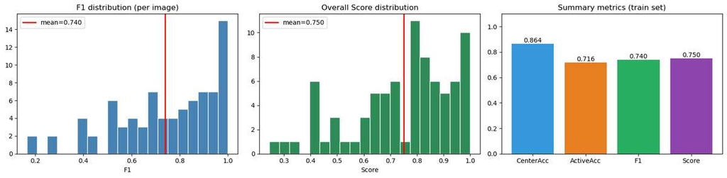

```python
# Score distribution
fig, axes = plt.subplots(1, 3, figsize=(16, 4))
axes[0].hist(df_res['f1'], bins=20, color='steelblue', edgecolor='white')
axes[0].axvline(df_res['f1'].mean(), color='red', lw=2, label=f'mean={df_res["f1"].mean():.3f}')
axes[0].set_title('F1 distribution (per image)')
axes[0].set_xlabel('F1'); axes[0].legend()

axes[1].hist(df_res['score'], bins=20, color='seagreen', edgecolor='white')
axes[1].axvline(df_res['score'].mean(), color='red', lw=2, label=f'mean={df_res["score"].mean():.3f}')
axes[1].set_title('Overall Score distribution')
axes[1].set_xlabel('Score'); axes[1].legend()

bar_data = {
    'CenterAcc': df_res.center_ok.mean(),
    'ActiveAcc': df_res.active_ok.mean(),
    'F1': df_res.f1.mean(),
    'Score': df_res.score.mean(),
}
axes[2].bar(bar_data.keys(), bar_data.values(),
             color=['#3498db','#e67e22','#27ae60','#8e44ad'])
for k, v in bar_data.items():
    axes[2].text(list(bar_data.keys()).index(k), v+0.01, f'{v:.3f}', ha='center', fontsize=10)
axes[2].set_ylim(0, 1.1)
axes[2].set_title('Summary metrics (train set)')

plt.tight_layout()
plt.show()
```

## 10. Ablation study — design choices

[output not shown]

### Why hybrid wins

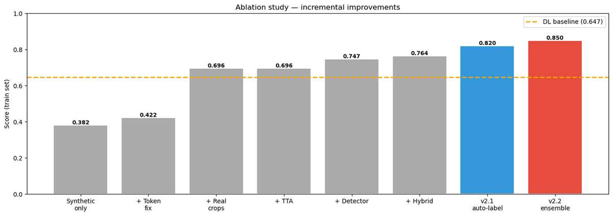

```python
# Ablation bar chart
ablation = {
    'Synthetic\nonly': 0.382,
    '+ Token\nfix': 0.422,
    '+ Real\ncrops': 0.696,
    '+ TTA': 0.696,
    '+ Detector': 0.747,
    '+ Hybrid': 0.764,
    'v2.1\nauto-label': 0.820,
    'v2.2\nensemble': 0.850,
}

fig, ax = plt.subplots(figsize=(14, 5))
colors = ['#aaaaaa']*6 + ['#3498db', '#e74c3c']
bars = ax.bar(ablation.keys(), ablation.values(), color=colors, edgecolor='white', linewidth=1.2)
for bar, val in zip(bars, ablation.values()):
    ax.text(bar.get_x() + bar.get_width()/2, val + 0.005, f'{val:.3f}',
            ha='center', fontsize=9, fontweight='bold')
ax.set_ylim(0, 1.0)
ax.axhline(0.647, color='orange', lw=2, ls='--', label='DL baseline (0.647)')
ax.set_ylabel('Score (train set)')
ax.set_title('Ablation study — incremental improvements')
ax.legend(fontsize=10)
plt.tight_layout()
plt.show()
```

## 11. Failure analysis

Cases where the pipeline struggles most.

```python
if len(df_res) > 0:
    worst = df_res.nsmallest(6, 'score')
    best  = df_res.nlargest(3, 'score')

    print('=== 6 worst predictions ===')
    print(worst[['image_id','center_ok','active_ok','f1','score']].to_string(index=False))
    print('\n=== 3 best predictions ===')
    print(best[['image_id','center_ok','active_ok','f1','score']].to_string(index=False))
```

```
=== 6 worst predictions ===
image_id  center_ok  active_ok       f1    score
L1000967          0          1 0.181818 0.245455
L1000973          1          0 0.266667 0.313333
L1000857          1          1 0.166667 0.333333
L1000978          0          0 0.500000 0.400000
L1000975          1          0 0.380952 0.404762
L1000971          1          1 0.266667 0.413333

=== 3 best predictions ===
image_id  center_ok  active_ok  f1  score
L1000770          1          1 1.0    1.0
L1000776          1          1 1.0    1.0
L1000780          1          1 1.0    1.0
```

[figure not shown]

[figure not shown]

[figure not shown]

```python
# Visualize the 3 worst cases
if len(df_res) > 0:
    for img_id in df_res.nsmallest(3, 'score')['image_id']:
        if (TRAIN_DIR / f'{img_id}.jpg').exists():
            visualize_prediction(img_id, df, classifier, detector, use_tta=True)
```

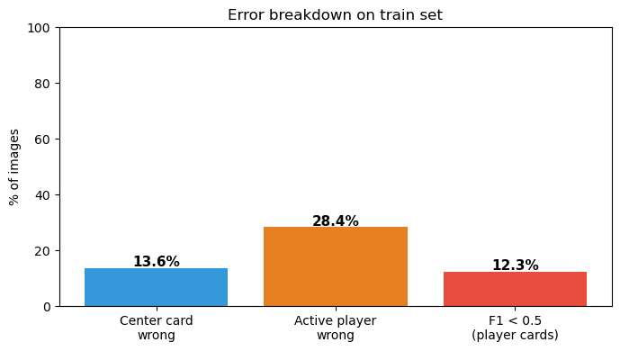

```python
# Error breakdown: what causes failures?
if len(df_res) > 0:
    center_fail = (df_res['center_ok'] == 0).sum()
    active_fail = (df_res['active_ok'] == 0).sum()
    low_f1 = (df_res['f1'] < 0.5).sum()
    n = len(df_res)

    fig, ax = plt.subplots(figsize=(7, 4))
    cats = ['Center card\nwrong', 'Active player\nwrong', 'F1 < 0.5\n(player cards)']
    vals = [center_fail/n*100, active_fail/n*100, low_f1/n*100]
    ax.bar(cats, vals, color=['#3498db','#e67e22','#e74c3c'])
    for i, v in enumerate(vals):
        ax.text(i, v+0.5, f'{v:.1f}%', ha='center', fontsize=11, fontweight='bold')
    ax.set_ylabel('% of images')
    ax.set_title('Error breakdown on train set')
    ax.set_ylim(0, 100)
    plt.tight_layout()
    plt.show()
```

## 12. What worked / What didn't

### What didn't work

1. **BG fringe augmentation alone** (0.420→0.418): Synthetic noisy backgrounds don't reproduce real leakage; caused false positives on foliage.
2. **Non-card class**: 55th class caused imbalance issues (1215 bg patches vs 54 templates), classifier over-rejected valid cards.
3. **Corner-detection approach (v3)**: Detecting 4 corners first then classifying — too many missed/false corners in cluttered scenes. Score peaked at 0.741 in hybrid with v2 classifier.
4. **NCC template matching for center card**: Normalized cross-correlation against 54 templates — CenterAcc 0.21, worse than CNN.
5. **First detector training**: All `obj_loss = 0` for 80 epochs. Root cause: `pos_mask = (target == 1.0)` selected no pixels because Gaussian heatmap max < 1.0 when center falls between grid cells. Fixed by forcing `obj_target[cy, cx] = 1.0` explicitly.

## 13. Reproducibility

[output not shown]

Checkpoints are committed at `outputs/models/classifier.pt` and `outputs/models/detector.pt`.